# exp preference

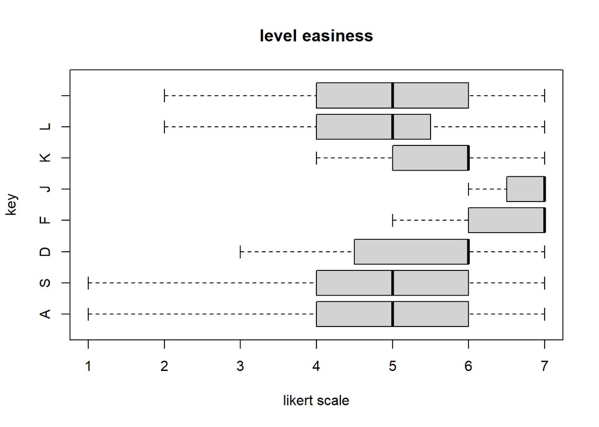

```r
ggsave("2level_easiness_level.pdf", width = 3, height = 2)


level2_data_key_long$ID = factor(level2_data_key_long$ID)
level2_data_key_long$Key = factor(level2_data_key_long$Key, key_code)

boxplot(Score~Key,data=level2_data_key_long, main="level easiness",
   xlab="likert scale", ylab="key", horizontal=TRUE, outline = FALSE)
```

```r
level2_data_key_summary <- level2_data_key_long %>%
  group_by(Key) %>%
  summarize(
    meanScore = Score %>% mean(na.rm=TRUE),
    lowCI = ci(Score)[2]%>% pmax(0),
    highCI = ci(Score)[3]%>% pmin(7),
    sd = ci(Score)[4],
    std = Score %>% sd())

level2_data_key_summary
```

```
## # A tibble: 8 × 6
##   Key       meanScore lowCI highCI    sd   std
##   <fct>         <dbl> <dbl>  <dbl> <dbl> <dbl>
## 1 A              4.71  3.99   5.43 0.348 1.71
## 2 S              4.71  4.04   5.37 0.321 1.57
## 3 D              5.42  4.86   5.97 0.269 1.32
## 4 F              6.38  5.91   6.84 0.224 1.10
## 5 J              6.54  6.17   6.91 0.180 0.884
## 6 K              5.54  5.03   6.05 0.248 1.22
## 7 L              4.75  4.26   5.24 0.235 1.15
## 8 Semicolon      4.92  4.26   5.57 0.318 1.56
```

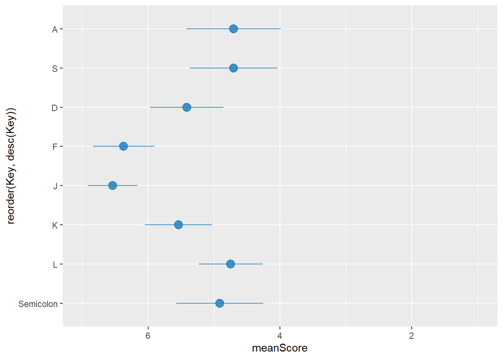

```r
# line + dot
level2_data_key_graph <- ggplot(level2_data_key_summary) +
  geom_pointrange( aes(x=reorder(Key, desc(Key)), y=meanScore, ymin=lowCI, ymax=highCI), colour="#2e86c1", alpha=0.9, size=0.8) +
  scale_y_reverse(lim=c(7,1)) +
  coord_flip()

level2_data_key_graph
```

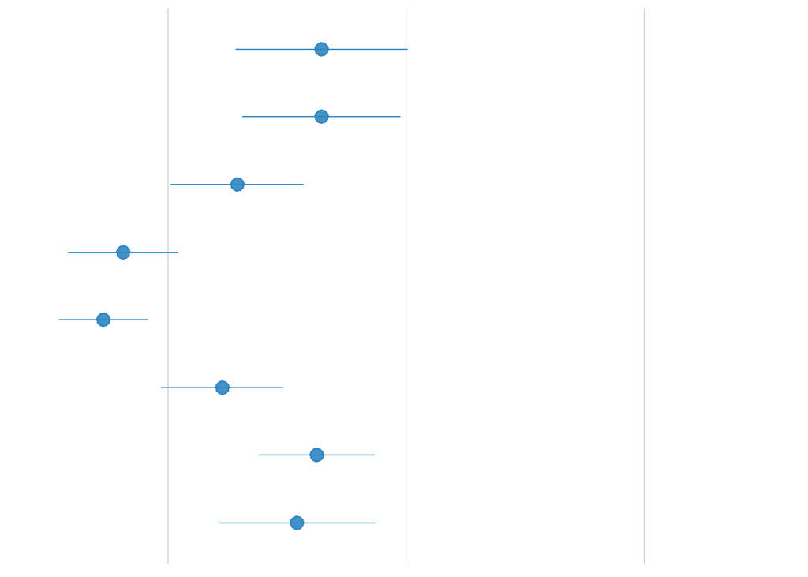

```r
level2_data_key_graph + theme( # remove the vertical grid lines
          panel.background = element_blank(),
          panel.grid.major.y = element_blank() ,
          # explicitly set the horizontal lines (or they will disappear too)
          panel.grid.major.x = element_line( size=.1, color="gray" ),
          axis.title.x = element_blank(),
          axis.text.x=element_blank(),
          axis.ticks.x = element_blank(),
          axis.title.y = element_blank(),
          axis.text.y=element_blank(),
          axis.ticks.y = element_blank()
    )
```

```r
ggsave("2level_easiness_key.pdf", width = 3, height = 8)
```

#### analysis

```r
m = aov(Score ~ Level, data=level2_data_level_long) # make anova-type linear model
shapiro.test(residuals(m))
```

```
##
##  Shapiro-Wilk normality test
##
## data:  residuals(m)
## W = 0.88463, p-value = 0.000208
```

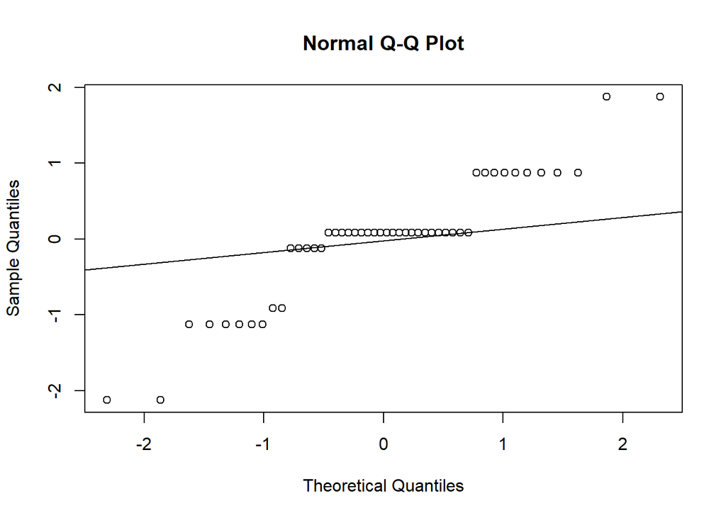

```r
qqnorm(residuals(m)); qqline(residuals(m)) # Q-Q plot
```

```r
# df has subjects (S), one within-Ss factor (X) w/levels (a,b,c), and continuous response (Y)
library(coin)
level2_data_level_long$ID = factor(level2_data_level_long$ID)
friedman_test(Score ~ Level | ID, data=level2_data_level_long, distribution="asymptotic")
```

```
##
##  Asymptotic Friedman Test
##
## data:  Score by Level (full, light)
##   stratified by ID
## chi-squared = 22, df = 1, p-value = 2.727e-06
```

```r
friedman_effsize(Score ~ Level | ID, data=level2_data_level_long)
```

```
## # A tibble: 1 × 5
##   .y.       n effsize method    magnitude
## * <chr> <int>   <dbl> <chr>     <ord>
## 1 Score    24   0.917 Kendall W large
```

```r
pairwise.wilcox.test(x = level2_data_level_long$Score,
                     g = level2_data_level_long$Level,
                     p.adjust.method = "holm",
                     paired = TRUE)
```

```
##
##  Pairwise comparisons using Wilcoxon signed rank test with continuity correction
##
## data:  level2_data_level_long$Score and level2_data_level_long$Level
##
##       full
## light 3.4e-05
##
## P value adjustment method: holm
```

```r
m = aov(Score ~ Key, data=level2_data_key_long) # make anova-type linear model
shapiro.test(residuals(m))
```

```
##
##  Shapiro-Wilk normality test
##
## data:  residuals(m)
## W = 0.95026, p-value = 3.088e-06
```

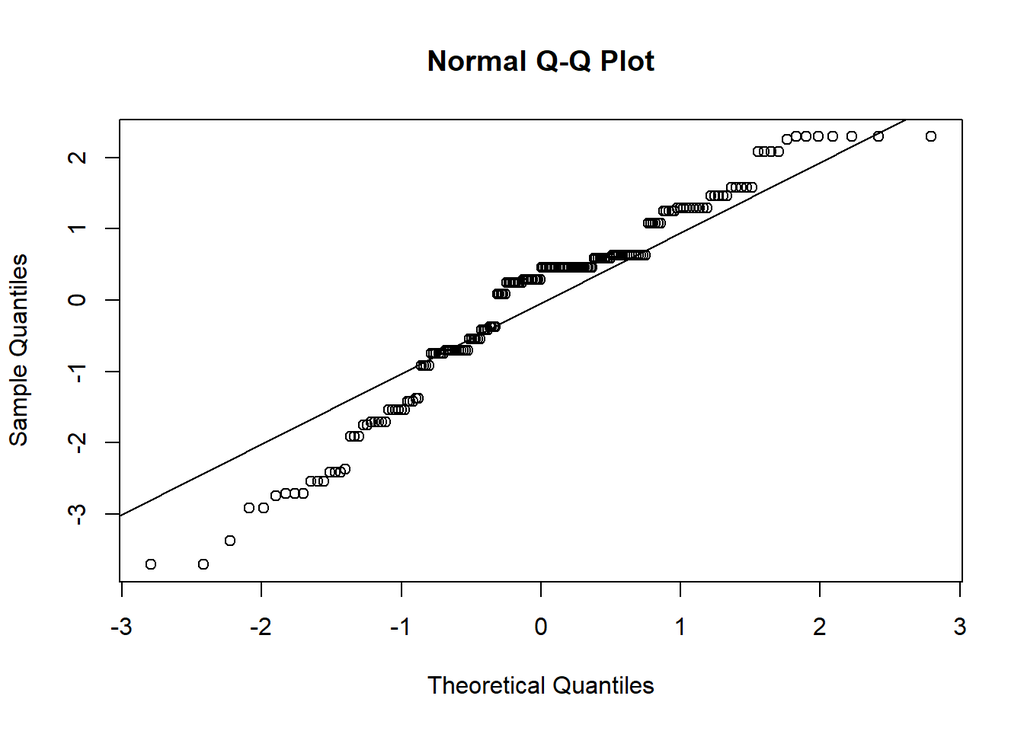

```r
qqnorm(residuals(m)); qqline(residuals(m)) # Q-Q plot
```

```r
# df has subjects (S), one within-Ss factor (X) w/levels (a,b,c), and continuous response (Y)
library(coin)
level2_data_key_long$ID = factor(level2_data_key_long$ID)
friedman_test(Score ~ Key | ID, data=level2_data_key_long, distribution="asymptotic")
```

```
##
##  Asymptotic Friedman Test
##
## data:  Score by
##   Key (A, S, D, F, J, K, L, Semicolon)
##   stratified by ID
## chi-squared = 65.531, df = 7, p-value = 1.176e-11
```

```r
friedman_effsize(Score ~ Key | ID, data=level2_data_key_long)
```

```
## # A tibble: 1 × 5
##   .y.       n effsize method    magnitude
## * <chr> <int>   <dbl> <chr>     <ord>
## 1 Score    24   0.390 Kendall W moderate
```

```r
pairwise.wilcox.test(x = level2_data_key_long$Score,
                     g = level2_data_key_long$Key,
                     p.adjust.method = "holm",
                     paired = TRUE)
```

```
##
##  Pairwise comparisons using Wilcoxon signed rank test with continuity correction
##
## data:  level2_data_key_long$Score and level2_data_key_long$Key
##
##           A      S      D      F      J      K      L
## S         1.0000 -      -      -      -      -      -
## D         0.4317 0.2169 -      -      -      -      -
## F         0.0068 0.0068 0.0102 -      -      -      -
## J         0.0095 0.0078 0.0339 1.0000 -      -      -
## K         0.4317 0.3684 1.0000 0.1272 0.0177 -      -
## L         1.0000 1.0000 0.3199 0.0019 0.0021 0.2520 -
## Semicolon 1.0000 1.0000 1.0000 0.0339 0.0260 1.0000 1.0000
##
## P value adjustment method: holm
```

Main effect on Level: Full is easier than Light Main effect on Key: (FJ) easier than (ASDL;), J easier than K

#### 3 level - easiness

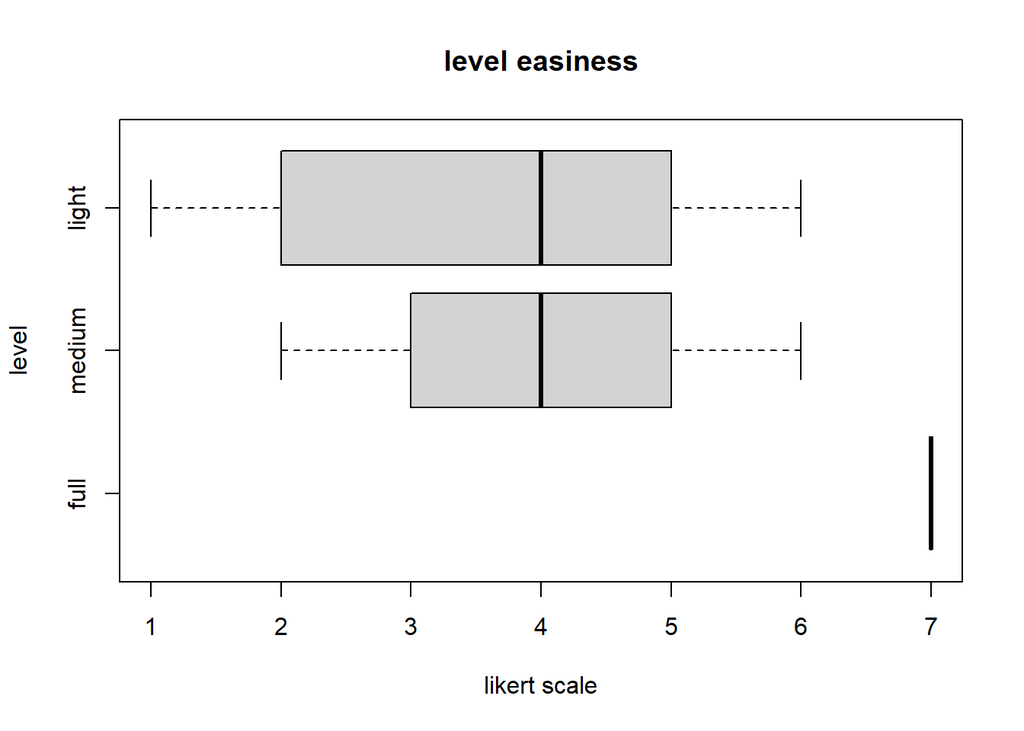

```r
level3_data_level <- level3_data %>%
  dplyr::select(ID, Light_easiness:Full_easiness)

colnames(level3_data_level) <- c("ID", "light", "medium", "full")

level3_data_level_long <- level3_data_level %>%
  pivot_longer(
    cols = light:full, # Selects columns that start with "Test"
    names_to = "Level",     # Name for the new column holding the original column names (e.g., Test1)
    values_to = "Score"        # Name for the new column holding the values (e.g., 85, 92)
  )

level3_data_key <- level3_data %>%
  dplyr::select(ID, A_easiness:Semicolon_easiness)

colnames(level3_data_key) <- c("ID", "A", "S", "D", "F", "J", "K", "L", "Semicolon")

level3_data_key_long <- level3_data_key %>%
  pivot_longer(
    cols = A:Semicolon, # Selects columns that start with "Test"
    names_to = "Key",     # Name for the new column holding the original column names (e.g., Test1)
    values_to = "Score"        # Name for the new column holding the values (e.g., 85, 92)
  )

level3_data_level_long$ID = factor(level3_data_level_long$ID)
level3_data_level_long$Level = factor(level3_data_level_long$Level, three_level_code)

boxplot(Score~Level,data=level3_data_level_long, main="level easiness",
   xlab="likert scale", ylab="level", horizontal=TRUE, outline = FALSE)
```

```r
level3_data_level_summary <- level3_data_level_long %>%
  group_by(Level) %>%
  summarize(
    meanScore = Score %>% mean(na.rm=TRUE),
    lowCI = ci(Score)[2]%>% pmax(0),
    highCI = ci(Score)[3]%>% pmin(7),
    sd = ci(Score)[4],
    std = Score %>% sd())

level3_data_level_summary
```

```
## # A tibble: 3 × 6
##   Level  meanScore lowCI highCI     sd   std
##   <fct>      <dbl> <dbl>  <dbl>  <dbl> <dbl>
## 1 full        6.96  6.87   7    0.0417 0.204
## 2 medium      3.75  3.23   4.27 0.25   1.22
## 3 light       3.58  2.86   4.31 0.351  1.72
```

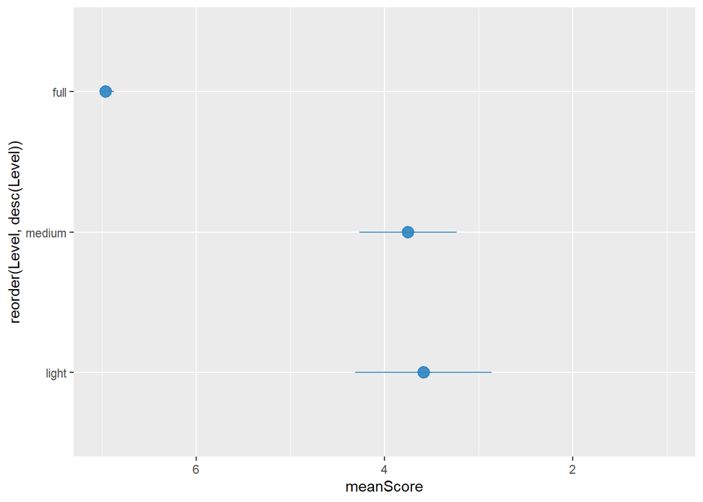

```r
# line + dot
level3_data_level_graph <- ggplot(level3_data_level_summary) +
  geom_pointrange( aes(x=reorder(Level, desc(Level)), y=meanScore, ymin=lowCI, ymax=highCI), colour="#2e86c1", alpha=0.9, size=0.8) +
  scale_y_reverse(lim=c(7,1)) +
  coord_flip()

level3_data_level_graph
```

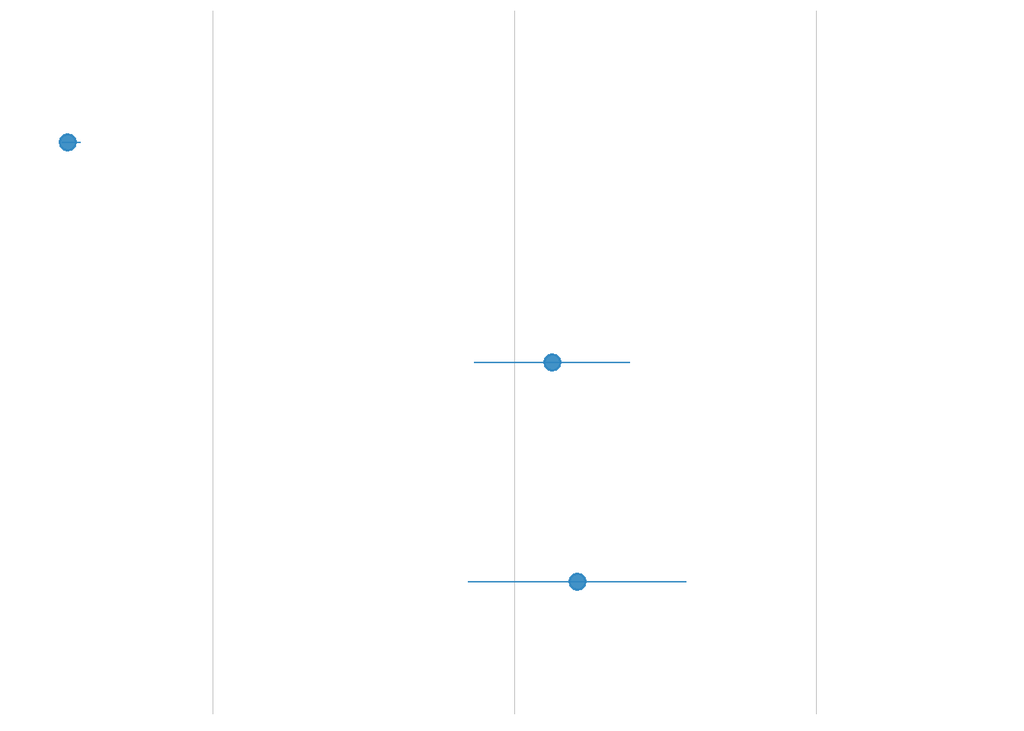

```r
level3_data_level_graph + theme( # remove the vertical grid lines
          panel.background = element_blank(),
          panel.grid.major.y = element_blank() ,
          # explicitly set the horizontal lines (or they will disappear too)
          panel.grid.major.x = element_line( size=.1, color="gray" ),
          axis.title.x = element_blank(),
          axis.text.x=element_blank(),
          axis.ticks.x = element_blank(),
          axis.title.y = element_blank(),
          axis.text.y=element_blank(),
          axis.ticks.y = element_blank()
    )
```

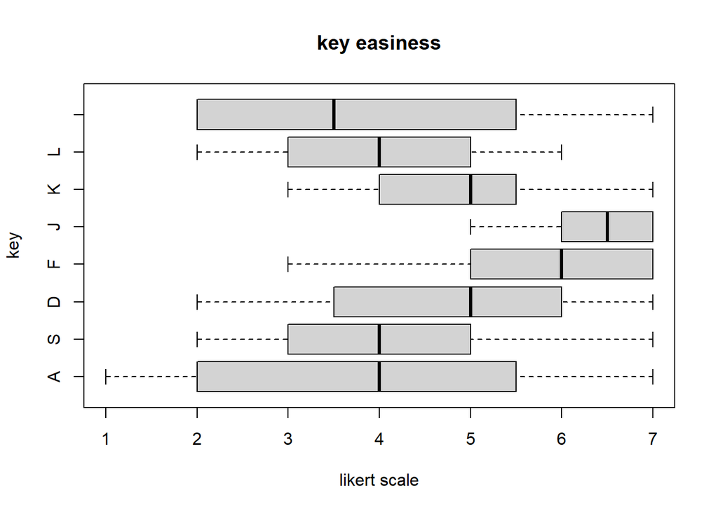

```r
ggsave("3level_easiness_level.pdf", width = 3, height = 3)


level3_data_key_long$ID = factor(level3_data_key_long$ID)
level3_data_key_long$Key = factor(level3_data_key_long$Key, key_code)

boxplot(Score~Key,data=level3_data_key_long, main="key easiness",
   xlab="likert scale", ylab="key", horizontal=TRUE, outline = FALSE)
```

```r
level3_data_key_summary <- level3_data_key_long %>%
  group_by(Key) %>%
  summarize(
    meanScore = Score %>% mean(na.rm=TRUE),
    lowCI = ci(Score)[2]%>% pmax(0),
    highCI = ci(Score)[3]%>% pmin(7),
    sd = ci(Score)[4],
    std = Score %>% sd())

level3_data_key_summary
```

```
## # A tibble: 8 × 6
##   Key       meanScore lowCI highCI    sd   std
##   <fct>         <dbl> <dbl>  <dbl> <dbl> <dbl>
## 1 A              3.88  3.09   4.66 0.377 1.85
## 2 S              4.04  3.41   4.67 0.304 1.49
## 3 D              4.71  4.06   5.36 0.316 1.55
## 4 F              6.08  5.64   6.53 0.216 1.06
## 5 J              6.29  5.93   6.65 0.175 0.859
## 6 K              5     4.53   5.47 0.225 1.10
## 7 L              4.12  3.58   4.67 0.265 1.30
## 8 Semicolon      3.96  3.20   4.72 0.369 1.81
```

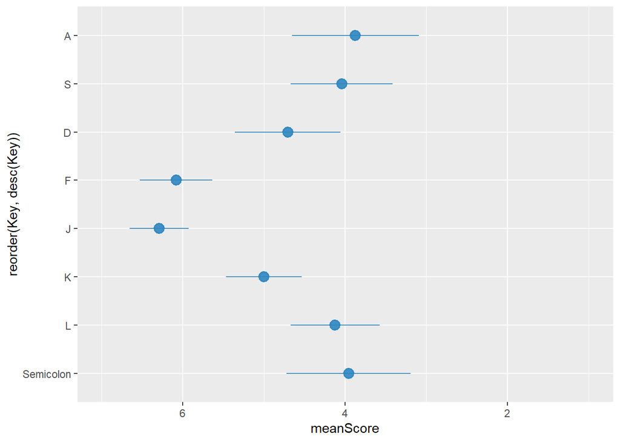

```r
# line + dot
level3_data_key_graph <- ggplot(level3_data_key_summary) +
  geom_pointrange( aes(x=reorder(Key, desc(Key)), y=meanScore, ymin=lowCI, ymax=highCI), colour="#2e86c1", alpha=0.9, size=0.8) +
  scale_y_reverse(lim=c(7,1)) +
  coord_flip()

level3_data_key_graph
```

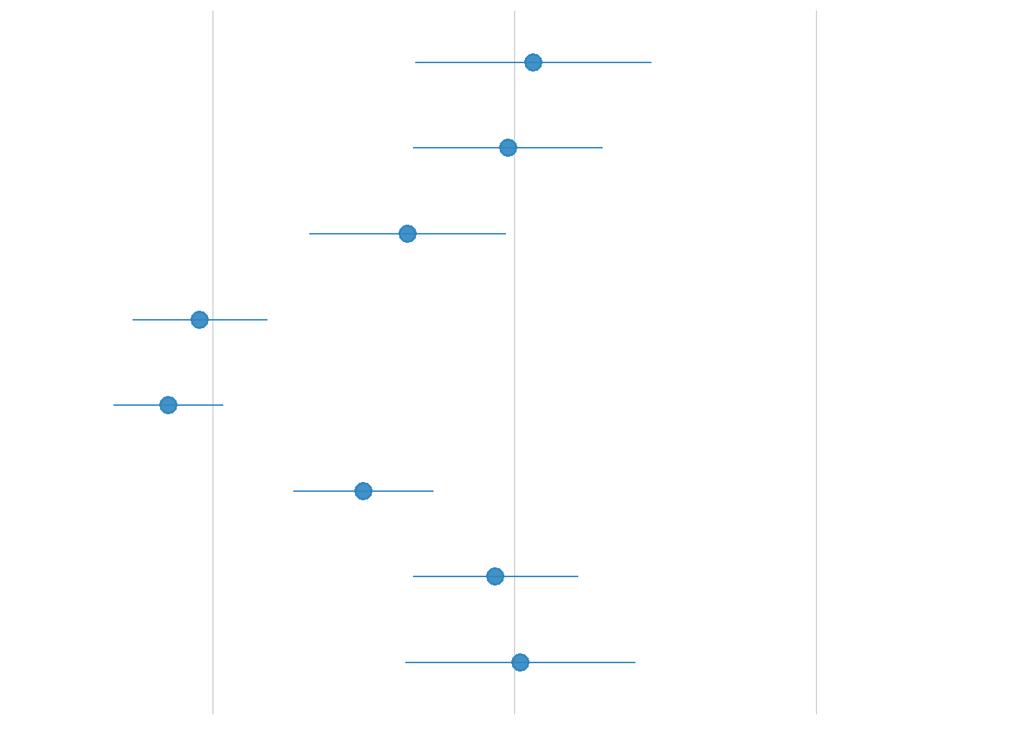

```r
level3_data_key_graph + theme( # remove the vertical grid lines
          panel.background = element_blank(),
          panel.grid.major.y = element_blank() ,
          # explicitly set the horizontal lines (or they will disappear too)
          panel.grid.major.x = element_line( size=.1, color="gray" ),
          axis.title.x = element_blank(),
          axis.text.x=element_blank(),
          axis.ticks.x = element_blank(),
          axis.title.y = element_blank(),
          axis.text.y=element_blank(),
          axis.ticks.y = element_blank()
    )
```

```r
ggsave("3level_easiness_key.pdf", width = 3, height = 8)
```

#### analysis

```r
m = aov(Score ~ Level, data=level3_data_level_long) # make anova-type linear model
shapiro.test(residuals(m))
```

```
##
##  Shapiro-Wilk normality test
##
## data:  residuals(m)
## W = 0.93283, p-value = 0.0008406
```

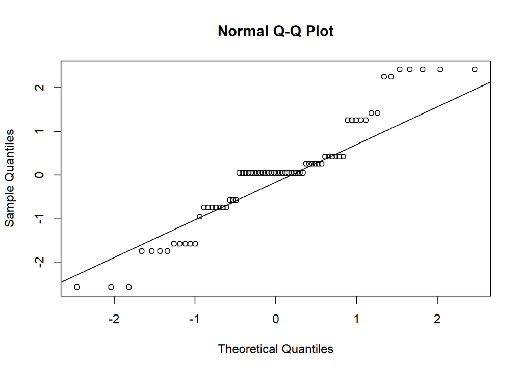

```r
qqnorm(residuals(m)); qqline(residuals(m)) # Q-Q plot
```

```r
# df has subjects (S), one within-Ss factor (X) w/levels (a,b,c), and continuous response (Y)
library(coin)
level3_data_level_long$ID = factor(level3_data_level_long$ID)
friedman_test(Score ~ Level | ID, data=level3_data_level_long, distribution="asymptotic")
```

```
##
##  Asymptotic Friedman Test
##
## data:  Score by
##   Level (full, medium, light)
##   stratified by ID
## chi-squared = 37.106, df = 2, p-value = 8.759e-09
```

```r
friedman_effsize(Score ~ Level | ID, data=level3_data_level_long)
```

```
## # A tibble: 1 × 5
##   .y.       n effsize method    magnitude
## * <chr> <int>   <dbl> <chr>     <ord>
## 1 Score    24   0.773 Kendall W large
```

```r
pairwise.wilcox.test(x = level3_data_level_long$Score,
                     g = level3_data_level_long$Level,
                     p.adjust.method = "holm",
                     paired = TRUE)
```

```
##
##  Pairwise comparisons using Wilcoxon signed rank test with continuity correction
##
## data:  level3_data_level_long$Score and level3_data_level_long$Level
##
##        full    medium
## medium 5.1e-05 -
## light  5.1e-05 0.8
##
## P value adjustment method: holm
```

```r
m = aov(Score ~ Key, data=level3_data_key_long) # make anova-type linear model
shapiro.test(residuals(m))
```

```
##
##  Shapiro-Wilk normality test
##
## data:  residuals(m)
## W = 0.97732, p-value = 0.00329
```

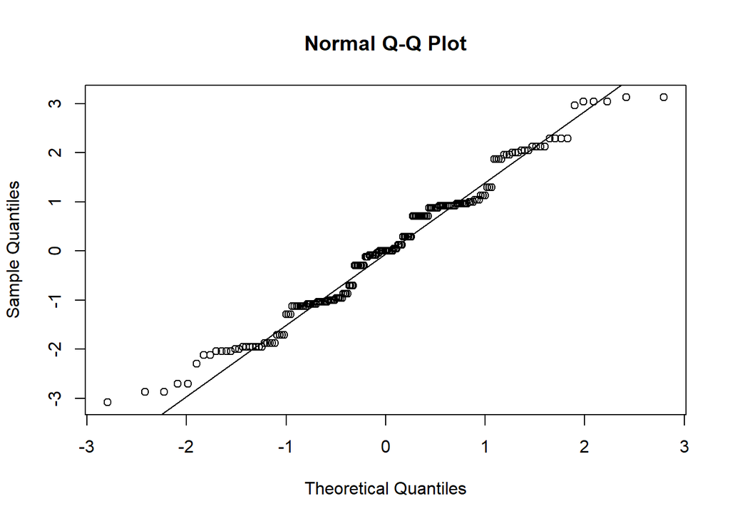

```r
qqnorm(residuals(m)); qqline(residuals(m)) # Q-Q plot
```

```r
# df has subjects (S), one within-Ss factor (X) w/levels (a,b,c), and continuous response (Y)
library(coin)
level3_data_key_long$ID = factor(level3_data_key_long$ID)
friedman_test(Score ~ Key | ID, data=level3_data_key_long, distribution="asymptotic")
```

```
##
##  Asymptotic Friedman Test
##
## data:  Score by
##   Key (A, S, D, F, J, K, L, Semicolon)
##   stratified by ID
## chi-squared = 76.594, df = 7, p-value = 6.806e-14
```

```r
friedman_effsize(Score ~ Key | ID, data=level3_data_key_long)
```

```
## # A tibble: 1 × 5
##   .y.       n effsize method    magnitude
## * <chr> <int>   <dbl> <chr>     <ord>
## 1 Score    24   0.456 Kendall W moderate
```

```r
pairwise.wilcox.test(x = level3_data_key_long$Score,
                     g = level3_data_key_long$Key,
                     p.adjust.method = "holm",
                     paired = TRUE)
```

```
##
##  Pairwise comparisons using Wilcoxon signed rank test with continuity correction
##
## data:  level3_data_key_long$Score and level3_data_key_long$Key
##
##           A      S      D      F      J      K      L
## S         1.0000 -      -      -      -      -      -
## D         0.4031 0.1722 -      -      -      -      -
## F         0.0023 0.0020 0.0053 -      -      -      -
## J         0.0031 0.0022 0.0081 1.0000 -      -      -
## K         0.1563 0.0782 1.0000 0.0246 0.0053 -      -
## L         1.0000 1.0000 0.6690 0.0019 0.0011 0.0282 -
## Semicolon 1.0000 1.0000 0.7605 0.0080 0.0035 0.1199 1.0000
##
## P value adjustment method: holm
```

Main effect on Level: Full is easier than light and medium Main effect on Key: (FJ) is easier than (ASDKL;), K is easier than L

#### 4 level - easiness

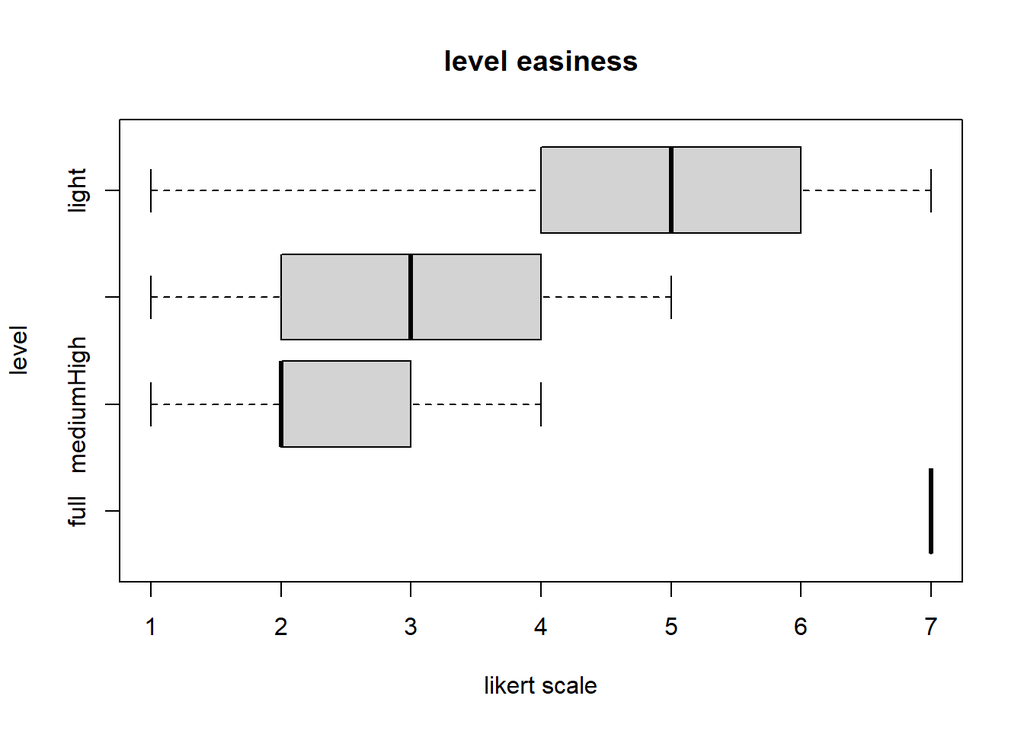

```r
level4_data_level <- level4_data %>%
  dplyr::select(ID, Light_easiness:Full_easiness)

colnames(level4_data_level) <- c("ID", "light", "mediumLow", "mediumHigh","full")

level4_data_level_long <- level4_data_level %>%
  pivot_longer(
    cols = light:full, # Selects columns that start with "Test"
    names_to = "Level",     # Name for the new column holding the original column names (e.g., Test1)
    values_to = "Score"        # Name for the new column holding the values (e.g., 85, 92)
  )

level4_data_key <- level4_data %>%
  dplyr::select(ID, A_easiness:Semicolon_easiness)

colnames(level4_data_key) <- c("ID", "A", "S", "D", "F", "J", "K", "L", "Semicolon")

level4_data_key_long <- level4_data_key %>%
  pivot_longer(
    cols = A:Semicolon, # Selects columns that start with "Test"
    names_to = "Key",     # Name for the new column holding the original column names (e.g., Test1)
    values_to = "Score"        # Name for the new column holding the values (e.g., 85, 92)
  )

level4_data_level_long$ID = factor(level4_data_level_long$ID)
level4_data_level_long$Level = factor(level4_data_level_long$Level, four_level_code)

boxplot(Score~Level,data=level4_data_level_long, main="level easiness",
   xlab="likert scale", ylab="level", horizontal=TRUE, outline = FALSE)
```

```r
level4_data_level_summary <- level4_data_level_long %>%
  group_by(Level) %>%
  summarize(
    meanScore = Score %>% mean(na.rm=TRUE),
    lowCI = ci(Score)[2]%>% pmax(0),
    highCI = ci(Score)[3]%>% pmin(7),
    sd = ci(Score)[4],
    std = Score %>% sd())

level4_data_level_summary
```

```
## # A tibble: 4 × 6
##   Level      meanScore lowCI highCI     sd   std
##   <fct>          <dbl> <dbl>  <dbl>  <dbl> <dbl>
## 1 full            6.92  6.80   7    0.0576 0.282
## 2 mediumHigh      2.54  2.11   2.97 0.208  1.02
## 3 mediumLow       3.04  2.58   3.50 0.221  1.08
## 4 light           4.79  4.11   5.47 0.330  1.61
```

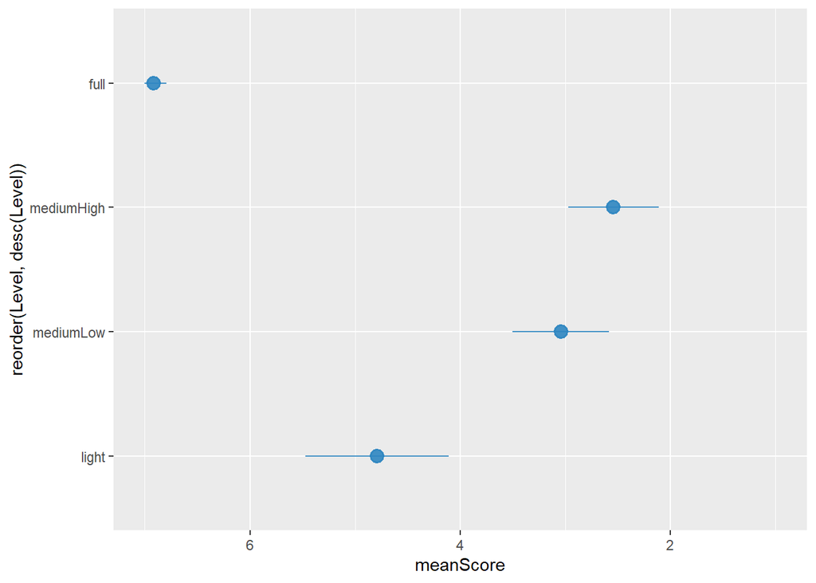

```r
# line + dot
level4_data_level_graph <- ggplot(level4_data_level_summary) +
  geom_pointrange( aes(x=reorder(Level, desc(Level)), y=meanScore, ymin=lowCI, ymax=highCI), colour="#2e86c1", alpha=0.9, size=0.8) +
  scale_y_reverse(lim=c(7,1)) +
  coord_flip()

level4_data_level_graph
```

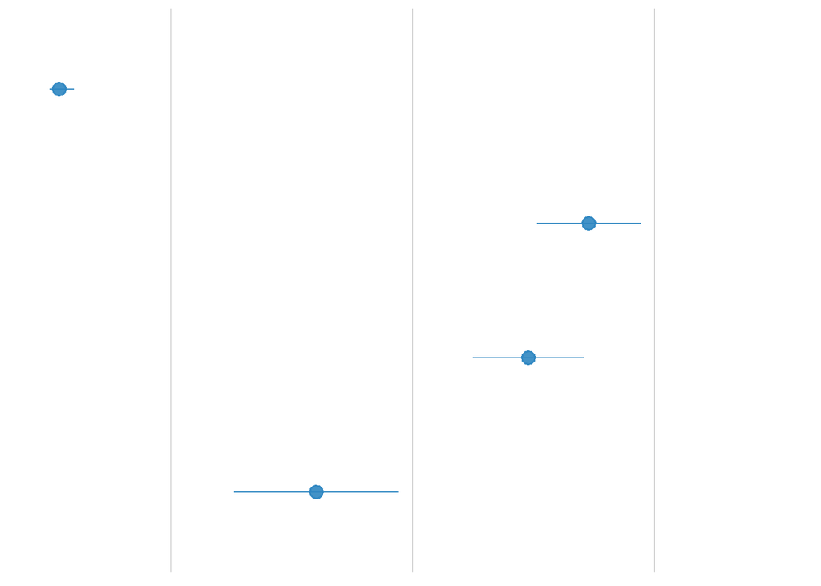

```r
level4_data_level_graph + theme( # remove the vertical grid lines
          panel.background = element_blank(),
          panel.grid.major.y = element_blank() ,
          # explicitly set the horizontal lines (or they will disappear too)
          panel.grid.major.x = element_line( size=.1, color="gray" ),
          axis.title.x = element_blank(),
          axis.text.x=element_blank(),
          axis.ticks.x = element_blank(),
          axis.title.y = element_blank(),
          axis.text.y=element_blank(),
          axis.ticks.y = element_blank()
    )
```

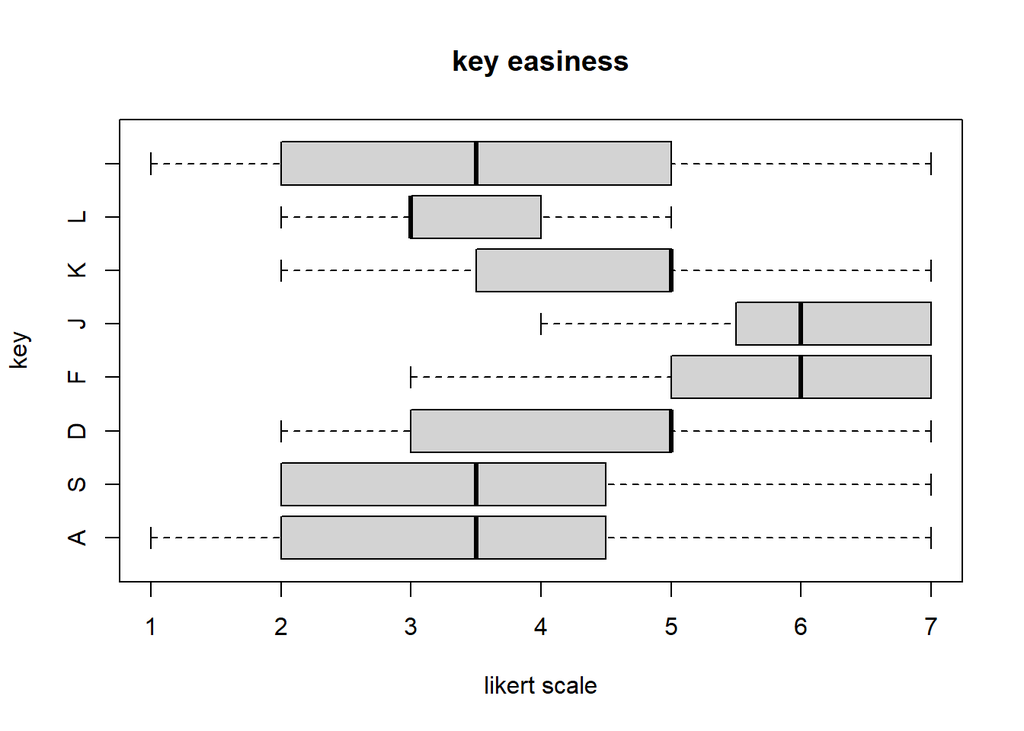

```r
ggsave("4level_easiness_level.pdf", width = 3, height = 4)


level4_data_key_long$ID = factor(level4_data_key_long$ID)
level4_data_key_long$Key = factor(level4_data_key_long$Key, key_code)

boxplot(Score~Key,data=level4_data_key_long, main="key easiness",
   xlab="likert scale", ylab="key", horizontal=TRUE, outline = FALSE)
```

```r
level4_data_key_summary <- level4_data_key_long %>%
  group_by(Key) %>%
  summarize(
    meanScore = Score %>% mean(na.rm=TRUE),
    lowCI = ci(Score)[2]%>% pmax(0),
    highCI = ci(Score)[3]%>% pmin(7),
    sd = ci(Score)[4],
    std = Score %>% sd())

level4_data_key_summary
```

```
## # A tibble: 8 × 6
##   Key       meanScore lowCI highCI    sd   std
##   <fct>         <dbl> <dbl>  <dbl> <dbl> <dbl>
## 1 A              3.62  2.87   4.38 0.365  1.79
## 2 S              3.67  3.01   4.32 0.317  1.55
## 3 D              4.46  3.82   5.09 0.307  1.50
## 4 F              5.71  5.09   6.32 0.298  1.46
## 5 J              5.79  5.19   6.39 0.289  1.41
## 6 K              4.54  3.96   5.13 0.282  1.38
## 7 L              3.5   3.00   4.00 0.241  1.18
## 8 Semicolon      3.58  2.84   4.33 0.361  1.77
```

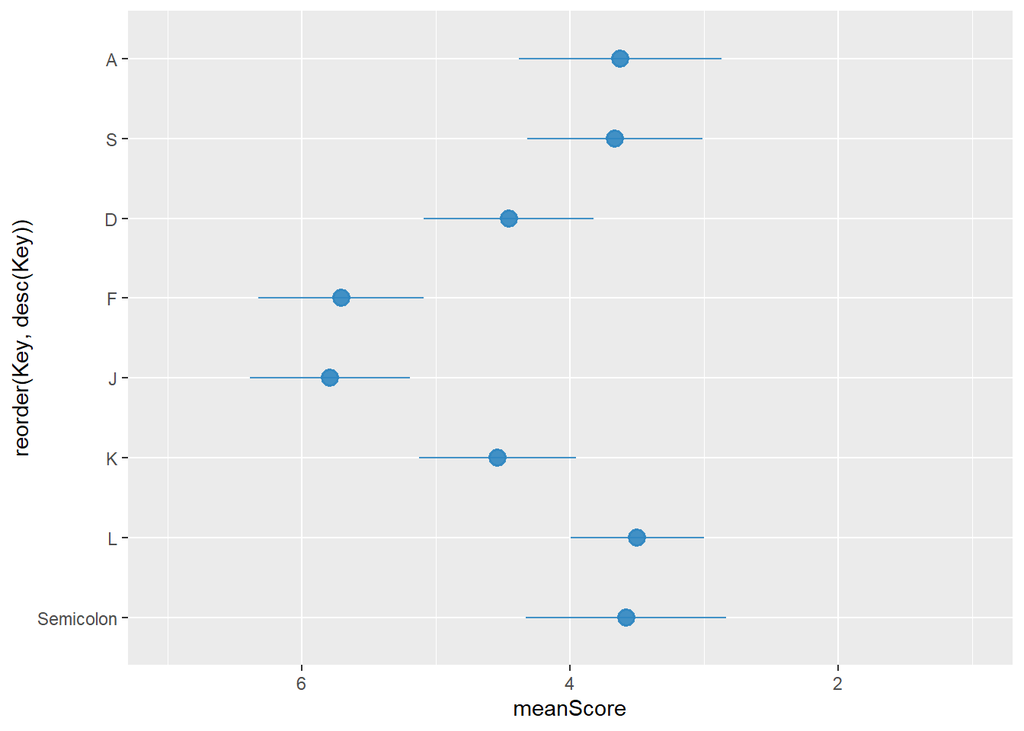

```r
# line + dot
level4_data_key_graph <- ggplot(level4_data_key_summary) +
  geom_pointrange( aes(x=reorder(Key, desc(Key)), y=meanScore, ymin=lowCI, ymax=highCI), colour="#2e86c1", alpha=0.9, size=0.8) +
  scale_y_reverse(lim=c(7,1)) +
  coord_flip()

level4_data_key_graph
```

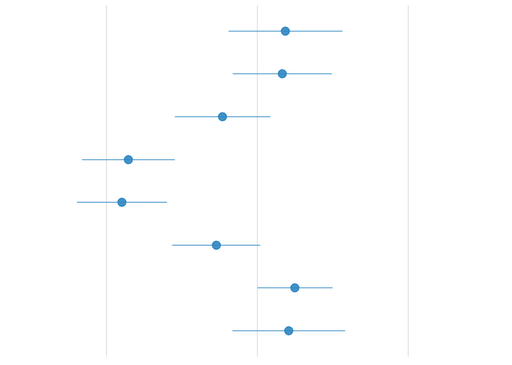

```r
level4_data_key_graph + theme( # remove the vertical grid lines
          panel.background = element_blank(),
          panel.grid.major.y = element_blank() ,
          # explicitly set the horizontal lines (or they will disappear too)
          panel.grid.major.x = element_line( size=.1, color="gray" ),
          axis.title.x = element_blank(),
          axis.text.x=element_blank(),
          axis.ticks.x = element_blank(),
          axis.title.y = element_blank(),
          axis.text.y=element_blank(),
          axis.ticks.y = element_blank()
    )
```

```r
ggsave("4level_easiness_key.pdf", width = 3, height = 8)
```

#### analysis

```r
m = aov(Score ~ Level, data=level4_data_level_long) # make anova-type linear model
shapiro.test(residuals(m))
```

```
##
##  Shapiro-Wilk normality test
##
## data:  residuals(m)
## W = 0.95316, p-value = 0.00176
```

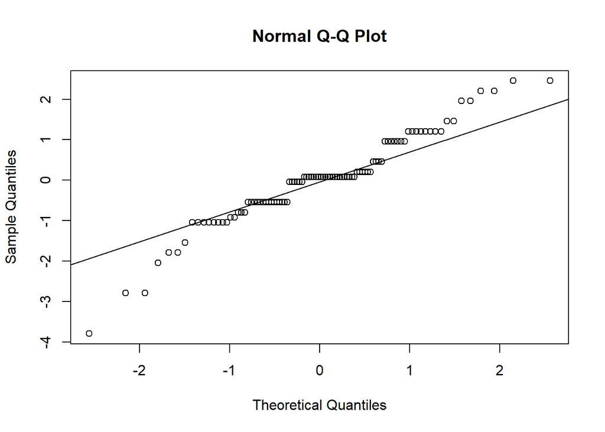

```r
qqnorm(residuals(m)); qqline(residuals(m)) # Q-Q plot
```

```r
# df has subjects (S), one within-Ss factor (X) w/levels (a,b,c), and continuous response (Y)
library(coin)
level4_data_level_long$ID = factor(level4_data_level_long$ID)
friedman_test(Score ~ Level | ID, data=level4_data_level_long, distribution="asymptotic")
```

```
##
##  Asymptotic Friedman Test
##
## data:  Score by
##   Level (full, mediumHigh, mediumLow, light)
##   stratified by ID
## chi-squared = 55.947, df = 3, p-value = 4.311e-12
```

```r
friedman_effsize(Score ~ Level | ID, data=level4_data_level_long)
```

```
## # A tibble: 1 × 5
##   .y.       n effsize method    magnitude
## * <chr> <int>   <dbl> <chr>     <ord>
## 1 Score    24   0.777 Kendall W large
```

```r
pairwise.wilcox.test(x = level4_data_level_long$Score,
                     g = level4_data_level_long$Level,
                     p.adjust.method = "holm",
                     paired = TRUE)
```

```
##
##  Pairwise comparisons using Wilcoxon signed rank test with continuity correction
##
## data:  level4_data_level_long$Score and level4_data_level_long$Level
##
##            full    mediumHigh mediumLow
## mediumHigh 7.2e-05 -          -
## mediumLow  8.2e-05 0.06826    -
## light      0.00014 0.00073    0.00206
##
## P value adjustment method: holm
```

```r
m = aov(Score ~ Key, data=level4_data_key_long) # make anova-type linear model
shapiro.test(residuals(m))
```

```
##
##  Shapiro-Wilk normality test
##
## data:  residuals(m)
## W = 0.97305, p-value = 0.0009245
```

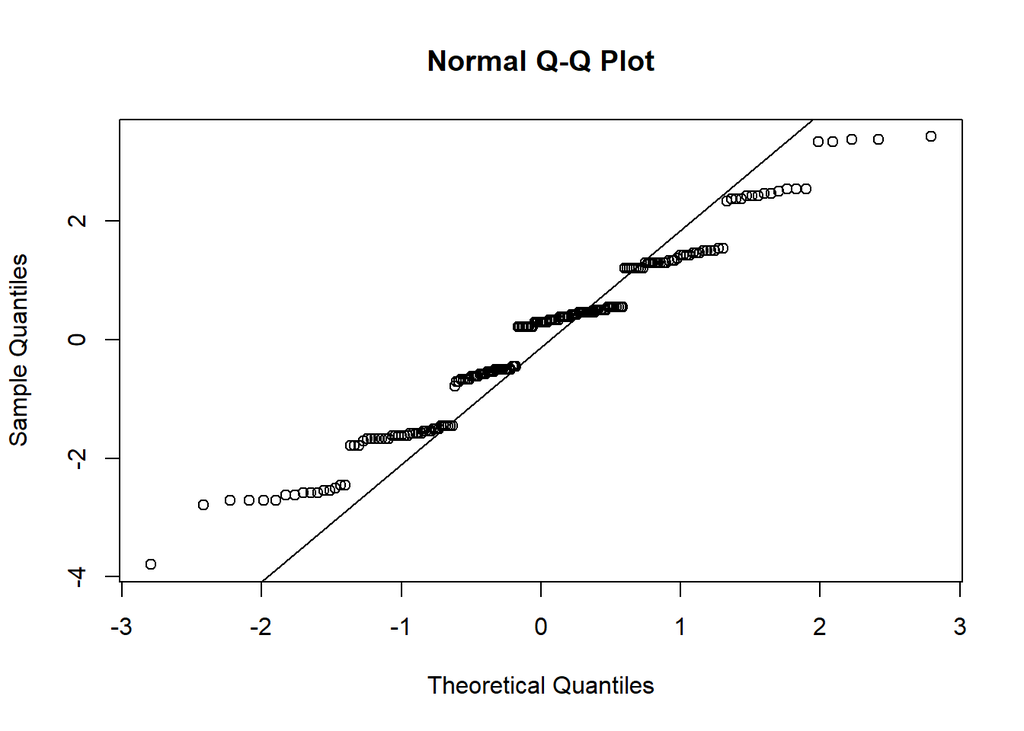

```r
qqnorm(residuals(m)); qqline(residuals(m)) # Q-Q plot
```

```r
# df has subjects (S), one within-Ss factor (X) w/levels (a,b,c), and continuous response (Y)
library(coin)
level4_data_key_long$ID = factor(level4_data_key_long$ID)
friedman_test(Score ~ Key | ID, data=level4_data_key_long, distribution="asymptotic")
```

```
##
##  Asymptotic Friedman Test
##
## data:  Score by
##   Key (A, S, D, F, J, K, L, Semicolon)
##   stratified by ID
## chi-squared = 64.274, df = 7, p-value = 2.103e-11
```

```r
friedman_effsize(Score ~ Key | ID, data=level4_data_key_long)
```

```
## # A tibble: 1 × 5
##   .y.       n effsize method    magnitude
## * <chr> <int>   <dbl> <chr>     <ord>
## 1 Score    24   0.383 Kendall W moderate
```

```r
pairwise.wilcox.test(x = level4_data_key_long$Score,
                     g = level4_data_key_long$Key,
                     p.adjust.method = "holm",
                     paired = TRUE)
```

```
##
##  Pairwise comparisons using Wilcoxon signed rank test with continuity correction
##
## data:  level4_data_key_long$Score and level4_data_key_long$Key
##
##           A      S      D      F      J      K      L
## S         1.0000 -      -      -      -      -      -
## D         0.3141 0.0836 -      -      -      -      -
## F         0.0047 0.0036 0.0051 -      -      -      -
## J         0.0226 0.0226 0.0211 1.0000 -      -      -
## K         0.3057 0.2117 1.0000 0.0326 0.0024 -      -
## L         1.0000 1.0000 0.0973 0.0045 0.0027 0.0503 -
## Semicolon 1.0000 1.0000 0.5391 0.0226 0.0290 0.4914 1.0000
##
## P value adjustment method: holm
```

Main effect on Level: full is easier than light, mediumLow, and mediumHigh; Light is easier than mediumLow, and mediumHigh Main effect on Key: (FJ) is easier than (ASDKL;)